# Systolic blood pressure in US adults

Dataset 10: NHANES adults (2009-10 and 2011-12 extract)

RSR feasibility analysis

2026-08-03

# Introduction

The National Health and Nutrition Examination Survey (NHANES) is a continuous cross-sectional survey of the civilian non-institutionalised US population, combining a household interview with a standardised physical examination in a mobile examination centre. This teaching extract holds 488 adults aged 21 to 80 from the 2009-10 and 2011-12 cycles. Systolic blood pressure is the single strongest modifiable determinant of stroke and ischaemic heart disease, so knowing which measured characteristics track with it is directly relevant to screening.

**Aim.** Among these US adults, we examined which of age, sex, race/ethnicity, BMI, income-to-poverty ratio, smoking history, alcohol frequency, diagnosed diabetes and recreational physical activity are independently associated with systolic blood pressure, mutually adjusting for the others.

This is a *Purpose 3* analysis: several predictors are of interest and the question is which remain associated with the outcome after mutual adjustment.

# Methods

**Data source.** NHANES 2009-10 and 2011-12, a complex multistage probability sample of the US civilian non-institutionalised population. This extract contains 488 adults (246 from 2009-10, 242 from 2011-12) with 31 variables. Blood pressure was measured in the mobile examination centre; the file carries the mean of the recorded readings, rounded to whole mmHg.

**Variables.** The outcome is `systolic_bp`, systolic blood pressure in mmHg, treated as continuous. Predictors are age (years), sex (reference female), race/ethnicity (reference White, the largest group), BMI (kg/m2), income-to-poverty ratio (household income as a multiple of the federal poverty line, higher = better off), ever having smoked 100 cigarettes (reference no), number of drinking days in the past year, doctor-diagnosed diabetes (reference no) and recreational moderate or vigorous physical activity (reference no).

`diastolic_bp` and `hypertensive` are deliberately excluded. `hypertensive` is not an independent variable at all: in this file it reproduces `systolic_bp >= 130 | diastolic_bp >= 80` exactly on every row where both pressures are observed, so putting it in the model would be regressing systolic pressure on a function of itself. `weight_kg` and `height_cm` are also excluded because `bmi` is exactly `weight_kg / (height_cm/100)^2` in this file (largest discrepancy 0.05 kg/m2, attributable to rounding), and the three cannot sit in one model without near-perfect collinearity.

**Statistical analysis.** `lm()`, justified because the outcome is continuous and approximately unimodal. We fitted a univariable model for each predictor first, then a single multivariable model containing all of them. Predictors were chosen in advance on subject-matter grounds, not by significance. Significance threshold 0.05; estimates are reported with 95% confidence intervals. Assumptions were checked with `performance::check_model()`, and because non-constant variance was flagged we additionally report HC3 heteroscedasticity-consistent standard errors. Models are **unweighted**: the NHANES survey weights, strata and primary sampling units are not carried in this extract, so no result here is a nationally representative estimate. Analysis used R version 4.6.0 (2026-04-24) with tidyverse, gtsummary and performance.

**Missing data.** Complete-case analysis: 368 of 488 rows were analysed (120 dropped). The two costly predictors are `alcohol_days_year` (88 missing) and `poverty_ratio` (38 missing); systolic pressure itself is missing for 20 participants. Only 172 of 488 rows are complete on *every* variable in the file, so listwise deletion is a live threat here and the complete-case N is reported for every model.

# Results

## Sample characteristics

**Table 1. Sample characteristics.**

| **Characteristic** | **N** | **N = 368**<sup>1</sup> |
| --- | --- | --- |
| Systolic BP (mmHg) | 368 | 120 (111, 130) |
| Age (years) | 368 | 50 (37, 63) |
| Sex | 368 |  |
| Female |  | 187 (51%) |
| Male |  | 181 (49%) |
| Race/ethnicity | 368 |  |
| White |  | 274 (74%) |
| Black |  | 41 (11%) |
| Hispanic |  | 14 (3.8%) |
| Mexican |  | 24 (6.5%) |
| Other |  | 15 (4.1%) |
| BMI (kg/m2) | 368 | 28 (25, 33) |
| Income-to-poverty ratio | 368 | 3.32 (1.71, 5.00) |
| Ever smoked 100+ cigarettes | 368 | 172 (47%) |
| Drinking days in past year | 368 | 24 (3, 104) |
| Diagnosed diabetes | 368 | 45 (12%) |
| Recreationally physically active | 368 | 193 (52%) |

<sup>1</sup> Median (Q1, Q3); n (%)

## Exploratory figure

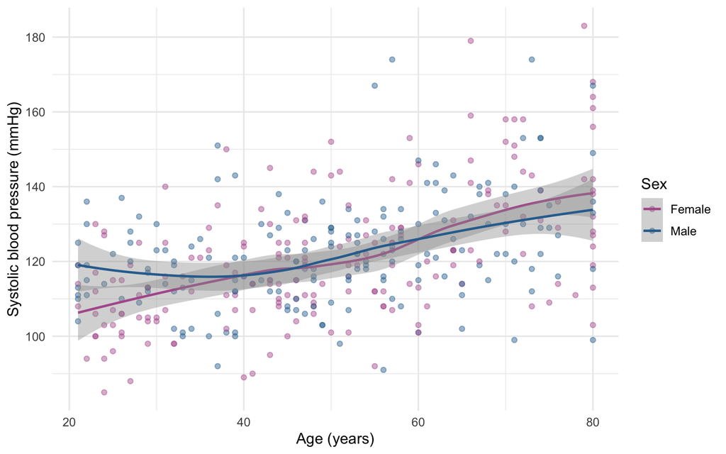

Figure 1. Systolic blood pressure against age, by sex, with LOESS smoothers.

## Univariable models

| **Characteristic** | **N** | **Beta** | **95% CI** | **p-value** |
| --- | --- | --- | --- | --- |
| Age (years) | 368 | 0.45 | 0.36, 0.54 | <0.001 |
| Sex | 368 |  |  |  |
| Female |  | — | — |  |
| Male |  | 0.86 | -2.5, 4.2 | 0.6 |
| Race/ethnicity | 368 |  |  |  |
| White |  | — | — |  |
| Black |  | -2.8 | -8.1, 2.5 | 0.3 |
| Hispanic |  | -6.9 | -16, 1.8 | 0.12 |
| Mexican |  | -2.0 | -8.7, 4.8 | 0.6 |
| Other |  | -11 | -19, -2.6 | 0.010 |
| BMI (kg/m2) | 368 | 0.18 | -0.07, 0.44 | 0.2 |
| Income-to-poverty ratio | 368 | 0.46 | -0.58, 1.5 | 0.4 |
| Ever smoked 100+ cigarettes | 368 |  |  |  |
| No |  | — | — |  |
| Yes |  | 1.2 | -2.2, 4.5 | 0.5 |
| Drinking days in past year | 368 | 0.02 | 0.00, 0.03 | 0.061 |
| Diagnosed diabetes | 368 |  |  |  |
| No |  | — | — |  |
| Yes |  | 10 | 5.1, 15 | <0.001 |
| Recreationally physically active | 368 |  |  |  |
| No |  | — | — |  |
| Yes |  | -0.32 | -3.6, 3.0 | 0.9 |

Abbreviation: CI = Confidence Interval

Age is the dominant crude predictor: each additional year of age is associated with 0.45 mmHg (95% CI 0.36 to 0.54) higher systolic pressure (p <0.001), so a 30-year age difference corresponds to roughly 13 mmHg. Diagnosed diabetes is associated with 10.05 mmHg (95% CI 5.09 to 15.00) (p <0.001) higher pressure crudely, and participants in the “Other” race category average -10.97 mmHg (95% CI -19.33 to -2.60) (p = 0.010) lower pressure than White participants. BMI, sex, income-to-poverty ratio, smoking, alcohol frequency and physical activity show no clear crude association.

## Why adjustment is needed

The crude estimates are confounded by age above all. **Age** is associated with almost every predictor here and with the outcome: older participants are far more likely to have diagnosed diabetes (diabetes prevalence rises steeply with age) and less likely to be recreationally active, and age independently raises systolic pressure through arterial stiffening. The crude diabetes coefficient of about 10 mmHg is therefore partly just the age difference between people with and without diabetes. **BMI** is the second obvious confounder: it is strongly associated with diabetes and with physical inactivity, and adiposity raises blood pressure through sodium retention and sympathetic activation, so the crude diabetes and activity coefficients also carry adiposity. **Sex** confounds the alcohol association, because men drink on more days per year and men and women differ in blood pressure at a given age. Mutual adjustment lets each coefficient be read as a comparison between participants who are similar on the other measured characteristics.

## Multivariable model

| **Characteristic** | **Beta** | **95% CI** | **p-value** |
| --- | --- | --- | --- |
| Age (years) | 0.43 | 0.33, 0.52 | <0.001 |
| Sex |  |  |  |
| Female | — | — |  |
| Male | 0.84 | -2.2, 3.9 | 0.6 |
| Race/ethnicity |  |  |  |
| White | — | — |  |
| Black | -0.59 | -5.4, 4.3 | 0.8 |
| Hispanic | -3.8 | -12, 4.1 | 0.3 |
| Mexican | 1.6 | -4.8, 7.9 | 0.6 |
| Other | -4.0 | -12, 3.8 | 0.3 |
| BMI (kg/m2) | 0.16 | -0.08, 0.39 | 0.2 |
| Income-to-poverty ratio | -0.26 | -1.3, 0.74 | 0.6 |
| Ever smoked 100+ cigarettes |  |  |  |
| No | — | — |  |
| Yes | 0.02 | -3.0, 3.0 | >0.9 |
| Drinking days in past year | 0.01 | -0.01, 0.02 | 0.3 |
| Diagnosed diabetes |  |  |  |
| No | — | — |  |
| Yes | 3.4 | -1.4, 8.3 | 0.2 |
| Recreationally physically active |  |  |  |
| No | — | — |  |
| Yes | 2.5 | -0.63, 5.7 | 0.12 |

Abbreviation: CI = Confidence Interval

**Model fit: multivariable linear model for systolic BP**

| Statistic | Value |
| --- | --- |
| Complete-case N | 368 |
| Parameters (excl. intercept) | 12 |
| R-squared | 0.240 |
| Adjusted R-squared | 0.214 |
| Residual SE (mmHg) | 14.32 |

The model explains 24.0% of the variance in systolic pressure (adjusted R-squared 0.214), which is modest but typical for blood pressure with demographic and behavioural predictors only. Among participants of the same sex, race, BMI, income level, smoking, drinking, diabetes and activity status, each additional year of age is associated with 0.43 mmHg (95% CI 0.33 to 0.52) higher systolic pressure (p <0.001). No other predictor reaches significance: diabetes is associated with 3.43 mmHg (95% CI -1.41 to 8.26) (p = 0.165), BMI with 0.16 mmHg (95% CI -0.08 to 0.39) per kg/m2 (p = 0.199), and being physically active with 2.51 mmHg (95% CI -0.63 to 5.66) (p = 0.116). These are associations among the participants observed, not effects of intervening on any of these variables.

## Unadjusted versus adjusted

**Table 2. Unadjusted and adjusted estimates.**

| **Characteristic** | **Unadjusted** **N** | **Unadjusted** **Beta** | **Unadjusted** **95% CI** | **Unadjusted** **p-value** | **Adjusted** **Beta** | **Adjusted** **95% CI** | **Adjusted** **p-value** |
| --- | --- | --- | --- | --- | --- | --- | --- |
| Age (years) | 368 | 0.45 | 0.36, 0.54 | <0.001 | 0.43 | 0.33, 0.52 | <0.001 |
| Sex | 368 |  |  |  |  |  |  |
| Female |  | — | — |  | — | — |  |
| Male |  | 0.86 | -2.5, 4.2 | 0.6 | 0.84 | -2.2, 3.9 | 0.6 |
| Race/ethnicity | 368 |  |  |  |  |  |  |
| White |  | — | — |  | — | — |  |
| Black |  | -2.8 | -8.1, 2.5 | 0.3 | -0.59 | -5.4, 4.3 | 0.8 |
| Hispanic |  | -6.9 | -16, 1.8 | 0.12 | -3.8 | -12, 4.1 | 0.3 |
| Mexican |  | -2.0 | -8.7, 4.8 | 0.6 | 1.6 | -4.8, 7.9 | 0.6 |
| Other |  | -11 | -19, -2.6 | 0.010 | -4.0 | -12, 3.8 | 0.3 |
| BMI (kg/m2) | 368 | 0.18 | -0.07, 0.44 | 0.2 | 0.16 | -0.08, 0.39 | 0.2 |
| Income-to-poverty ratio | 368 | 0.46 | -0.58, 1.5 | 0.4 | -0.26 | -1.3, 0.74 | 0.6 |
| Ever smoked 100+ cigarettes | 368 |  |  |  |  |  |  |
| No |  | — | — |  | — | — |  |
| Yes |  | 1.2 | -2.2, 4.5 | 0.5 | 0.02 | -3.0, 3.0 | >0.9 |
| Drinking days in past year | 368 | 0.02 | 0.00, 0.03 | 0.061 | 0.01 | -0.01, 0.02 | 0.3 |
| Diagnosed diabetes | 368 |  |  |  |  |  |  |
| No |  | — | — |  | — | — |  |
| Yes |  | 10 | 5.1, 15 | <0.001 | 3.4 | -1.4, 8.3 | 0.2 |
| Recreationally physically active | 368 |  |  |  |  |  |  |
| No |  | — | — |  | — | — |  |
| Yes |  | -0.32 | -3.6, 3.0 | 0.9 | 2.5 | -0.63, 5.7 | 0.12 |

Abbreviation: CI = Confidence Interval

Two coefficients move a long way toward the null. Diabetes falls from 10.05 mmHg (95% CI 5.09 to 15.00) crude to 3.43 mmHg (95% CI -1.41 to 8.26) adjusted and loses significance, a drop of about two thirds; this is confounding by age and BMI, exactly as anticipated, and the residual estimate is too imprecise to interpret. Race “Other” moves from -10.97 mmHg (95% CI -19.33 to -2.60) (significant) to -3.95 mmHg (95% CI -11.74 to 3.83) (not significant), a shift explained by the much younger age (mean 40 vs 52 years) and lower BMI (mean 24 vs 29 kg/m2) of that group, which is very small here (n = 15). Physical activity moves in the opposite direction, from -0.32 mmHg (95% CI -3.64 to 3.00) crude to 2.51 mmHg (95% CI -0.63 to 5.66) adjusted: once age and BMI are held constant, active participants have slightly *higher* rather than slightly lower pressure, a sign that the crude estimate was masked by the fact that active people are younger and leaner. Age itself barely moves (0.45 mmHg (95% CI 0.36 to 0.54) to 0.43 mmHg (95% CI 0.33 to 0.52)), which is what you expect for a variable that confounds the others but is itself confounded by nothing measured here. Nothing crosses into significance on adjustment.

## Diagnostics

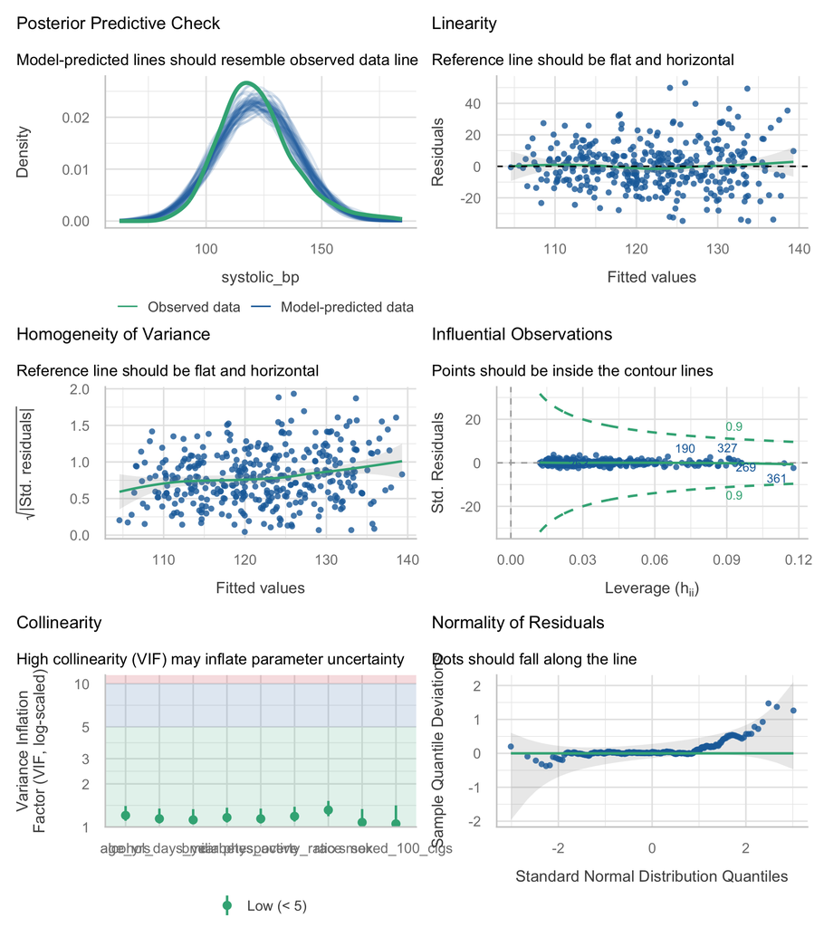

**Table 3. HC3 heteroscedasticity-consistent standard errors.**

| Term | Estimate | SE (OLS) | SE (HC3) | 95% CI (HC3) | p (HC3) |
| --- | --- | --- | --- | --- | --- |
| age_yrs | 0.427 | 0.049 | 0.054 | 0.32 to 0.53 | 0.000 |
| sexMale | 0.845 | 1.550 | 1.539 | -2.18 to 3.87 | 0.583 |
| raceBlack | -0.586 | 2.461 | 2.389 | -5.28 to 4.11 | 0.806 |
| raceHispanic | -3.763 | 3.996 | 4.214 | -12.05 to 4.53 | 0.373 |
| raceMexican | 1.554 | 3.249 | 3.892 | -6.10 to 9.21 | 0.690 |
| raceOther | -3.955 | 3.960 | 3.294 | -10.43 to 2.52 | 0.231 |
| bmi | 0.156 | 0.121 | 0.148 | -0.14 to 0.45 | 0.293 |
| poverty_ratio | -0.264 | 0.512 | 0.474 | -1.20 to 0.67 | 0.578 |
| smoked_100_cigsYes | 0.021 | 1.535 | 1.564 | -3.06 to 3.10 | 0.989 |
| alcohol_days_year | 0.007 | 0.008 | 0.008 | -0.01 to 0.02 | 0.384 |
| diabetesYes | 3.426 | 2.460 | 2.897 | -2.27 to 9.12 | 0.238 |
| phys_activeYes | 2.515 | 1.597 | 1.637 | -0.70 to 5.73 | 0.125 |

The posterior-predictive and residual panels show the model captures the centre of the distribution but under-predicts the upper tail: a handful of participants with systolic pressures above 170 mmHg are poorly fitted. The residual-versus- fitted panel fans out toward higher fitted values, and `check_heteroscedasticity()` confirms non-constant error variance (p < 0.001) - the spread of systolic pressure genuinely grows with its mean. The normal-QQ panel shows a heavy right tail, consistent with the same few high-pressure participants. Collinearity is a non-issue: the highest VIF is 1.31, for race/ethnicity. No point exceeds the Cook’s distance contours, so no single observation drives the fit.

Because variance is non-constant, Table 3 reports HC3 robust standard errors. The HC3 SE for age is 0.054 against an OLS SE of 0.049, so the age conclusion is unchanged; no predictor changes its significance status under robust inference. The point estimates are unaffected - only the uncertainty around them is re-estimated.

# Discussion

In this NHANES extract, age is the only characteristic independently associated with systolic blood pressure once the others are held constant, at roughly 0.43 mmHg per year. The crude diabetes association, which looked large and highly significant, is substantially explained by the age and BMI differences between participants with and without diabetes. Practically, this reinforces that age is the dominant stratifier for blood-pressure screening, and that a crude comparison of pressure across diabetes status will badly overstate the difference attributable to diabetes itself.

**Limitations.** The models are unweighted, and the NHANES sampling weights, strata and PSUs are not in this extract, so the sample **must not be described as nationally representative**: minority groups are oversampled by design and standard errors ignore the clustered multistage design, which typically makes them too small. The design is cross-sectional, so nothing here establishes temporality - diabetes, activity and blood pressure were measured at the same visit. Complete-case analysis dropped 120 of 488 rows (25%), mostly for missing alcohol and income data, and if those data are not missing at random the estimates are biased. Non-constant residual variance was detected and handled with HC3 SEs, but the heavy right tail means predictions for hypertensive participants are poor. Antihypertensive medication is not recorded in this extract, which is a serious unmeasured confounder: treated participants have lower measured pressure *because* of their higher underlying risk, biasing the diabetes and BMI coefficients toward the null. Race/ethnicity categories are small outside White (n = 94 in total across four groups) so those contrasts are imprecise. All estimates are associations, not causal effects.

**Future work.** Refit with the NHANES survey design using the `survey` package and add antihypertensive medication use, which is available in the full public NHANES files.

# Feasibility notes

*NOT part of a student report.*

- **Works well as a student project.** Continuous, well-measured outcome; one large, unambiguous, easily interpreted signal (age); several predictors that attenuate on adjustment, which is exactly the teaching point of Purpose 3.
- **Complete-case N drops to 368 of 488 (25% lost).** Driven by `alcohol_days_year` (18% missing) and `poverty_ratio` (8% missing) plus the 20 rows missing blood pressure. Dropping `alcohol_days_year` recovers about 60 rows. Students will not notice this unless told to check.
- **Trap: `hypertensive` and `diastolic_bp` must be excluded.** `hypertensive` is an exact recomputation of `systolic_bp >= 130 | diastolic_bp >= 80` on all 468 rows with both pressures observed (100% agreement; the 20 apparent exceptions are simply rows where BP is missing, so `hypertensive` is missing too). A student who includes it will get a huge R-squared and an incoherent model.
- **Trap: `bmi`, `weight_kg`, `height_cm`.** `bmi` is exactly `weight_kg/(height_cm/100)^2` (max absolute discrepancy 0.05, pure rounding). All three in one model gives severe collinearity.
- **Heteroscedasticity is real and flagged (p < 0.001)**, plus non-normal residuals with a heavy right tail. This is a feature, not a bug: it gives the student a genuine reason to run `check_heteroscedasticity()` and HC3, and the conclusions survive.
- **Low R-squared (0.240)** may disappoint students expecting a “good” model; worth pre-empting.
- **Unweighted survey analysis.** Must be stated. The extract carries no weights, strata or PSU, so a design-based analysis is impossible with this file alone.
- No separation, no collinearity (max VIF 1.31), no influential-point problems.